# Manejo de Texto con datos del API

## Problema 1: ¿Hay títulos repetidos?

Una pregunta lógica que podemos hacernos es saber si hay títulos repetidos en la base de datos. El que haya títulos repetidos nos dice que hay notas que, o están duplicadas, o hablan de los mismos temas (aunque esto no es necesariamente cierto).

Con el siguiente código exploraremos si hay notas repetidas.

```r
# Forma Facil
table(datos$title[duplicated(datos$title)]) %>% head()
```

```
##
##                                                                            Agenda Confidencial
##                                                                                              1
##                          Al día, 25 quejas por tarifas <span style="color: red">de</span> agua
##                                                                                              1
## Atienden unidades <span style="color: red">de</span> emergencia 102 encharcamientos por lluvia
##                                                                                              1
##                                                                                Capital federal
##                                                                                              1
##                                                                                      CAPITANES
##                                                                                              1
##                                                                     CARBAJAL INVERSION CHIAPAS
##                                                                                             16
```

En la tabla anterior, tenemos notas repetidas que posiblemente nos esten dando la misma información, sin embargo, están desordenadas. Una forma facil de generar una tabla donde los títulos están ordenados de mayor a menor repetición es mediante el siguiente código:

```r
# Forma tidy
datos$title[duplicated(datos$title)] %>%
  as_tibble() %>%
  group_by(value) %>%
  summarise(n = n()) %>%
  arrange(desc(n))
```

```
## # A tibble: 56 x 2
##    value                                                       n
##    <chr>                                                   <int>
##  1 Pronostico del tiempo                                     192
##  2 Pronóstico del tiempo                                     189
##  3 CARBAJAL INVERSION CHIAPAS                                 16
##  4 Pronóstico del clima                                        4
##  5 CARDENAS LLUVIAS DF                                         3
##  6 Columnas: CORPORATIVO                                       3
##  7 "Cronista <span style=\"color: red\">de</span> guardia"     3
##  8 LLUVIA DISTRITO FEDERAL                                     3
##  9 Un Vistazo                                                  3
## 10 Desde la región más transparente                            2
## # … with 46 more rows
```

Como podemos observar, `Pronostico del tiempo` se repite demasiadas veces y no aporta a nuestro objetivo principal (el conocer los eventos e inundación en la Ciudad de México). Igualmente, `CARBAJAL INVERSIÓN CHIAPAS` ni `Columnas: CORPORATIVO` se ven de mucha utilidad, y sin embargo, se repiten bastante. **Nos haremos cargo posteriormente de estos casos, por ahora lo dejaremos así.**

## Problema 2. Eliminación de los HTML tags.

Los tags nos sirven para darle formato a páginas web, sin embargo, no nos interesa tenerlos a la hora del análisis. Para detectar estos patrones, utilizaremos `expresiones regulares`.

```r
# ELIMINAMOS LOS TAGS #

# patron_sencillo <- or1(c('<span style="color: red">','</span>'))
# <regex>
patron_sencillo <- '(?:<span style="color: red">|</span>)'

# patron_complejo <- '<' %R% optional('/') %R% captura(WRD %R% optional(SPC) %R% optional(char_class("\":=!"))) %R% ">"
# regex>
patron_complejo <- '<[/]?([\\w[\\s]?[":=!]?]+)>'

# Extraemos las palabras
str_extract_all(datos$title, patron_sencillo) %>% unlist() %>% niveles() # Nos damos cuenta de que solo hay 2 niveles... pero y si hubiera mas?
```

```
## [1] "</span>"                     "<span style=\"color: red\">"
```

```r
str_extract_all(datos$title, patron_complejo) %>% unlist() %>% niveles() # Caso General
```

```
## [1] "</span>"                     "<span style=\"color: red\">"
```

```r
str_view_all(datos$title[1:10], pattern = patron_sencillo, match = T)
```

[interactive chart not shown]

```r
datos$title <- str_remove(datos$title, pattern = patron_complejo)
View(datos)
# No elimino todo!!! -- CHECAR LA MODIFICACION
datos$title <- str_remove_all(datos$title, pattern = patron_complejo)

# Y en otras variables
str_extract_all(datos$abstract[1], pattern = patron_complejo)
```

```
## [[1]]
## [1] "<span style=\"color: red\">" "</span>"
## [3] "<span style=\"color: red\">" "</span>"
## [5] "<span style=\"color: red\">" "</span>"
```

```r
str_extract_all(datos$body[1], pattern = patron_complejo)
```

```
## [[1]]
##  [1] "<!UNIGEN548>"                "<h3>"
##  [3] "</h3>"                       "<span style=\"color: red\">"
##  [5] "</span>"                     "<span style=\"color: red\">"
##  [7] "</span>"                     "<span style=\"color: red\">"
##  [9] "</span>"                     "<span style=\"color: red\">"
## [11] "</span>"                     "<p>"
```

Como podemos ver arriba, el `patron_sencillo` no hubiera capturado los tags `<!UNIGEN548>` o los `<h3>`, porque no los consideraba específicamente. Por eso es mejor el `patron_complejo`, ya que es una solución más general.

## Problema 3. Queremos ver que periódicos aportaron mas a nuestra base.

```r
# 1. Detectamos que celdas tienen Economista o El Universal o el EXCELSIOR como periodico Principal
niveles(datos$periodico)
```

```
##  [1] "DPA - Political News"
##  [2] "El Economista - Online Edition"
##  [3] "El Economista - Print Edition"
##  [4] "El Financiero - Financial Newspaper"
##  [5] "El Universal - Financial News"
##  [6] "El Universal - International News"
##  [7] "El Universal - National News"
##  [8] "El Universal-Mexico City and States"
##  [9] "Excelsior - Print Edition"
## [10] "Excelsior Online -Newspaper"
## [11] "Milenio Diario D.F."
## [12] "National and International News"
## [13] "Reforma Newspaper - Daily News"
```

```r
# 2. Detectamos los patrones

# Approach: Eliminando todo lo que este despues del signo
#pat_guion <-  "-" %R% captura(WRD %R% SPC) %R% END
pat_guion <- "-([\\w\\s]+)$"
str_view(datos$periodico[1:15], pat_guion, match = T)
```

[interactive chart not shown]

```r
datos$periodico <- str_remove_all(datos$periodico, pattern = pat_guion)
niveles(datos$periodico)[1:10] # Se repite el UNIVERSAL! Por que?
```

```
##  [1] "DPA "                            "El Economista "
##  [3] "El Financiero "                  "El Universal"
##  [5] "El Universal "                   "Excelsior "
##  [7] "Excelsior Online "               "Milenio Diario D.F."
##  [9] "National and International News" "Reforma Newspaper "
```

```r
# Rehacemos el patron
#pat_guion <-  optional(SPC) %R% "-" %R% captura(WRD %R% SPC) %R% END
pat_guion <- '[\\s]?-([\\w\\s]+)$'
datos$periodico <- str_remove_all(datos$periodico, pattern = pat_guion)
niveles(datos$periodico) # Se repite el UNIVERSAL! Por que?
```

```
##  [1] "DPA "                            "El Economista "
##  [3] "El Financiero "                  "El Universal"
##  [5] "El Universal "                   "Excelsior "
##  [7] "Excelsior Online "               "Milenio Diario D.F."
##  [9] "National and International News" "Reforma Newspaper "
```

```r
# R: El espacio del final... como lo eliminamos?
#pat_espacio_final <- SPC %R% END
pat_espacio_final <- "\\s$"
datos$periodico <- str_remove_all(datos$periodico, pattern = pat_espacio_final)

# Y si en vez de DPA queremos volver a tener DPA-NEWS?
datos$periodico <- str_replace_all(datos$periodico, pattern = "DPA", replacement = "DPA - Political News")
datos$periodico <- str_replace_all(datos$periodico, pattern = "Excelsior Online", replacement = "Excelsior")
niveles(datos$periodico)
```

```
## [1] "DPA - Political News"            "El Economista"
## [3] "El Financiero"                   "El Universal"
## [5] "Excelsior"                       "Milenio Diario D.F."
## [7] "National and International News" "Reforma Newspaper"
```

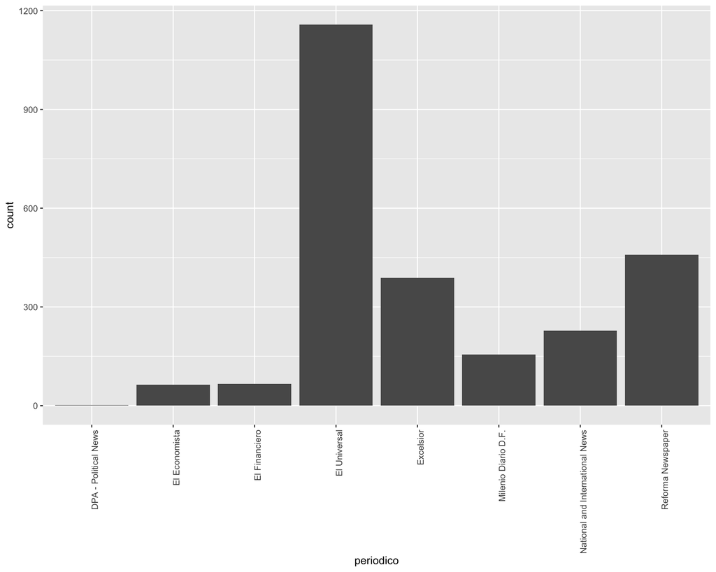

```r
# Visualizamos datos
ggplot(data = datos, aes(x = periodico)) + geom_bar() + theme(axis.text.x = element_text(angle = 90, hjust = 1))
```

```r
#ggplot(data = datos, aes(x = periodico, fill = periodico)) + geom_bar() + theme_minimal() + scale_color_brewer("Blues")
```

## Problema 4. Eliminar noticias que no son de interés.

Como pudimos ver en el *Problema 1*, hay muchas noticias repetidas y que no aportan información útil al problema. Utilizaremos la librería `stringr` para poder eliminar estas noticias de nuestra base de datos.

```r
##################################################################
# ELIMINAR NOTICIAS Y QUEDARME SOLO CON LAS QUE DICEN INUNDACION #
##################################################################

# Tidy repaso! Vemos las noticias repetidas!
FREC <- datos$title %>%
  as_data_frame() %>%
  group_by(value) %>%
  summarise(n = n()) %>%
  arrange(desc(n))

# Visualizamos
FREC
```

```
## # A tibble: 2,053 x 2
##    value                                n
##    <chr>                            <int>
##  1 Pronostico del tiempo              193
##  2 Pronóstico del tiempo              190
##  3 CARBAJAL INVERSION CHIAPAS          17
##  4 Pronóstico del clima                 5
##  5 CARDENAS LLUVIAS DF                  4
##  6 Columnas: CORPORATIVO                4
##  7 Cronista de guardia                  4
##  8 LLUVIA DISTRITO FEDERAL              4
##  9 Un Vistazo                           4
## 10 Desde la región más transparente     3
## # … with 2,043 more rows
```

```r
#-----------------#
# E L I M I N A R
#-----------------#

# Generamos una variable con datos en Minusculas
# NOTA! De esta manera es mas facil trabajar con expresiones regulares!
# Pero no es obligatorio
datos$minus <- tolower(datos$title)      # Convertimos a minusculas
palabras <- c( "pronóstico del tiempo" ,
               "pronostico del tiempo",
               "chiapas",
               "veracruz",
               "crême",
               "hermanos fuentes",
               "cardenas visita")

#pat_noticias <- rebus::or1(palabras)
pat_noticias <- paste0("(?:", paste(palabras, collapse = "|"), ")")

str_view_all(datos$minus[1:15], pattern = pat_noticias, match = T)
```

[interactive chart not shown]

```r
# Generamos dummy!
datos$noticia_inservible <-  str_detect(datos$minus, pattern = pat_noticias)

datos <- datos %>%
  filter(noticia_inservible != TRUE)

# Quedarme solo con las que dicen inundacion # T i d y
noticias_inundacion <- datos %>%
  mutate(tiene_inundacion = str_detect(minus, pattern = "inundaci")) %>%
  filter(tiene_inundacion == TRUE) %>%
  select(minus, tiene_inundacion)

# Inundacion o lluvias
noticias_inundacion_lluvias <- datos %>%
  mutate(tiene_inundacion = str_detect(minus, pattern = or1(c("inundaci","lluvia")))) %>%
  filter(tiene_inundacion == TRUE) %>%
  select(minus, tiene_inundacion, body)

# LIMPIAMOS TAGS
noticias_inundacion_lluvias$body <- str_remove_all(noticias_inundacion_lluvias$body, pattern = patron_complejo)
```

## Problema 5. Queremos saber que palabras se repiten más.

Para hacer limpieza de palabras y exploración de la base de datos, haremos un wordCloud para averigüar que temas se repiten más frecuentemente.

```r
# Creamos nube de palabras
source("https://raw.githubusercontent.com/JuveCampos/DataEng/master/R/create_fast_wordCloud.R")
create_wordcloud(noticias_inundacion_lluvias$body, stop_words = c("méxico", "ciudad", "así"), num_words = 200)
```

[interactive chart not shown]

```r
# Frecuencia palabras
freq_palabras[1:30,]
```

```
##               word freq
## 1          lluvias 1134
## 2             agua 1120
## 3     inundaciones  838
## 4           lluvia  786
## 5          federal  616
## 6          sistema  582
## 7            aguas  562
## 8             zona  555
## 9         gobierno  513
## 10             mil  484
## 11      protección  483
## 12           civil  466
## 13         drenaje  465
## 14        distrito  462
```

[output cut: 16 more lines]